# prefviz

A visualization toolkit for preferential data

## Seeking feedbacks

1. **Presentation:** Any parts you wish to get more explanations or Any redundant parts?
2. **Applications:** Is there any use cases you think would be interesting to explore?

# Part 1

**What is preferential data?**

## Data that captures rankings, not just first choices

> Preferential data record how people rank alternatives, not just which option they choose first.

**Common contexts:**

- Elections — voters rank candidates
- Consumer surveys — rank products
- Food research — rank dishes, wines, flavours

[figure not shown]

Australian ballot paper

# Part 2

**Forms of preferential data**

## The same rankings can be stored in multiple shapes

**Wide** — one row per voter

| Voter | 1st | 2nd | 3rd |
| --- | --- | --- | --- |
| Alice | Coffee | Coke | OJ |
| Ben | Coke | OJ | Coffee |
| Carla | OJ | Coffee | Coke |

**Long** — one row per voter–item pair

| voter | item | rank |
| --- | --- | --- |
| Alice | Coffee | 1 |
| Alice | Coke | 2 |
| Alice | OJ | 3 |
| Ben | Coffee | 2 |
| Ben | Coke | 1 |
| Ben | OJ | 3 |
| Carla | Coffee | 3 |
| Carla | Coke | 2 |
| Carla | OJ | 1 |

## PrefLib — a standard format for ranked data

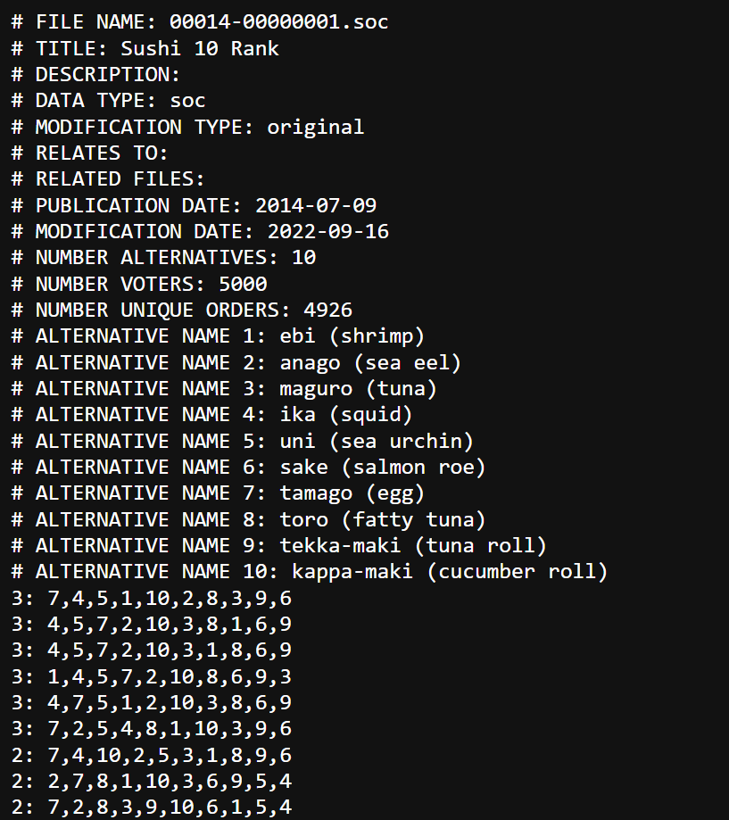

PrefLib data format

Ranked datasets exist in **structured exchange formats** beyond rectangular tables.

**Adopt `prefio` as the tidy approach.**

Read PrefLib files, convert between forms, aggregate ballot counts — use **`prefio`**.

# Part 3

**Visualisation for preferential data**

## Scope: exploratory analysis, not model output

**Covered**

Inspecting the **structure of raw preferential data** — before or alongside modelling.

**Not covered**

Visualising outputs from preference models (mixed logit, Bradley–Terry, Plackett–Luce, …).

**Two organising questions:**

1. What are the **general preferences** in the data?
2. How do we **compare multiple elections** or preference contexts?

## Pairwise comparison — `pairwise_heatmap`

*Data: 5000 respondents ranking 10 sushi types (PrefLib)*

- Plot
- Code

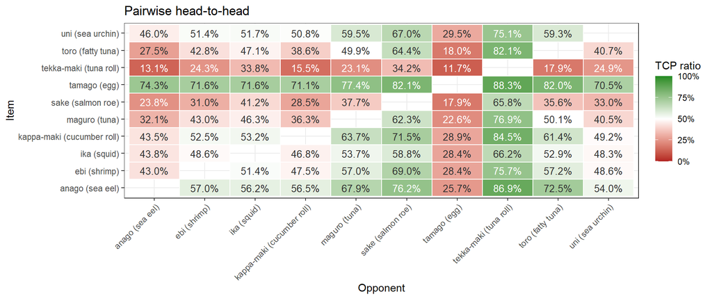

```r
sushi_data <- prefio::read_preflib(
  "00014 - sushi/00014-00000001.soc",
  from_preflib = TRUE
)

pw_result <- pairwise_calculator(
  sushi_data,
  preferences_col = preferences,
  frequency_col   = frequency
)

pairwise_heatmap(pw_result, value = "tcp")
```

## Distribution of preference — `dop_bar`

*Data: 5000 respondents ranking 10 sushi types (PrefLib)*

- Plot
- Code

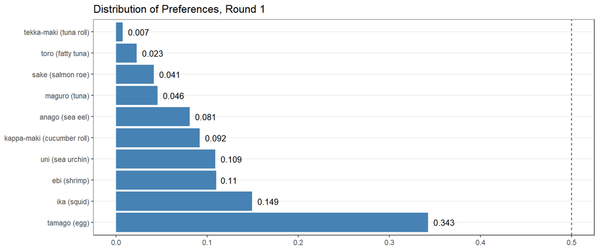

```r
# Compute the IRV rounds
irv_tbl <- dop_irv(
  sushi_data,
  value_type      = "percent",
  preferences_col = preferences,
  frequency_col   = frequency
)

# Plot
dop_bar(irv_tbl, -c(round, winner), at_round = 1)
```

## Ternary plots — all electorates at once

A stepping stone from simple summaries to higher-dimensional exploration

- Plot
- Code

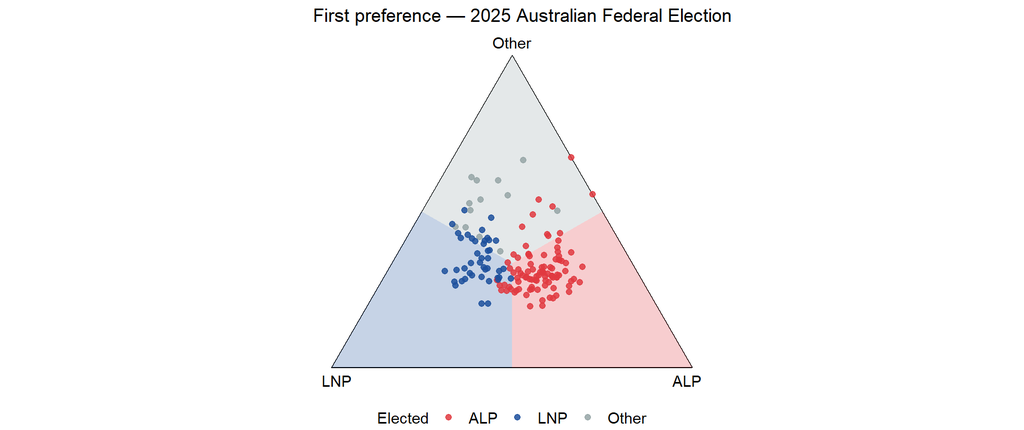

```r
tern_2d <- as_ternable(pref25_2d, items = ALP:Other)

input_data <- get_tern_data(tern_2d, plot_type = "2D")

ggplot(input_data |> filter(CountNumber == 0),
       aes(x = x1, y = x2)) +
  add_ternary_base() +
  geom_ternary_region(
    x1 = 1/3, x2 = 1/3, x3 = 1/3,
    aes(fill = after_stat(vertex_labels)),
    vertex_labels = tern_2d$vertex_labels,
    alpha = 0.3, color = NA) +
  add_vertex_labels(tern_2d$simplex_vertices) +
  geom_point(aes(color = Winner)) +
  scale_color_manual(values = party_colors)
```

## Ternary path — tracking one observation across rounds

*How a single electorate’s composition shifts as candidates are eliminated*

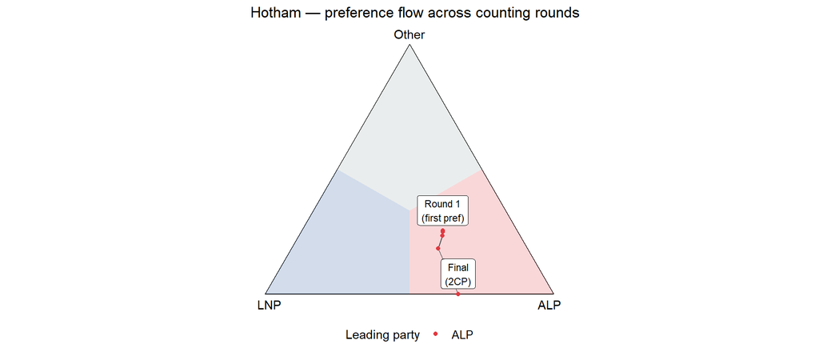

## How to read ternary plot

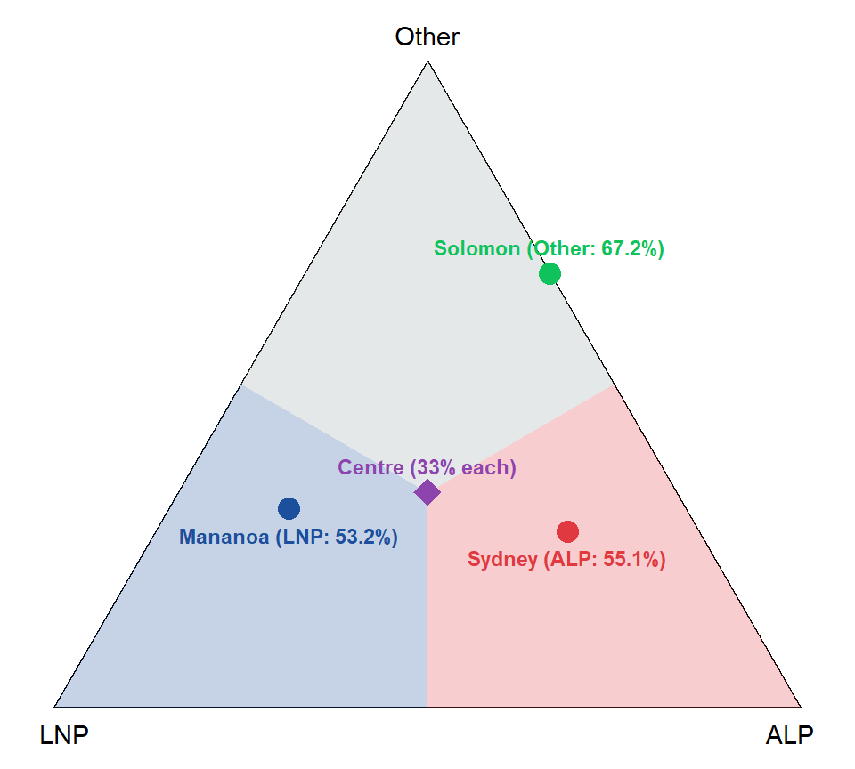

- Each **dot** = one electorate
- Three components: **ALP %, LNP %, Other %**
- All 150 electorates visible **at once**
- Position in the triangle encodes composition

# Part 4

**Case study: Australian House of Representatives**

## Package code structure

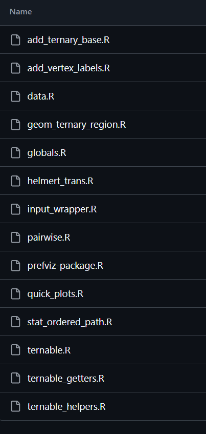

## Main functions

[output not shown]

## `ternable` object

A `ternable` object contains the data and metadata necessary for ternary plots, including the **vertices, edges, labels** of the simplex, and **coordinates** of all data points.

```r
tern_2d <- as_ternable(pref25_2d, items = ALP:Other)
```

- **`ternary_coords`** - coordinates of all data points
- **`simplex_vertices`** - coordinates of the 3 corners
- **`simplex_edges`** - pairs connecting vertices
- **`vertex_labels`** - party names at each corner

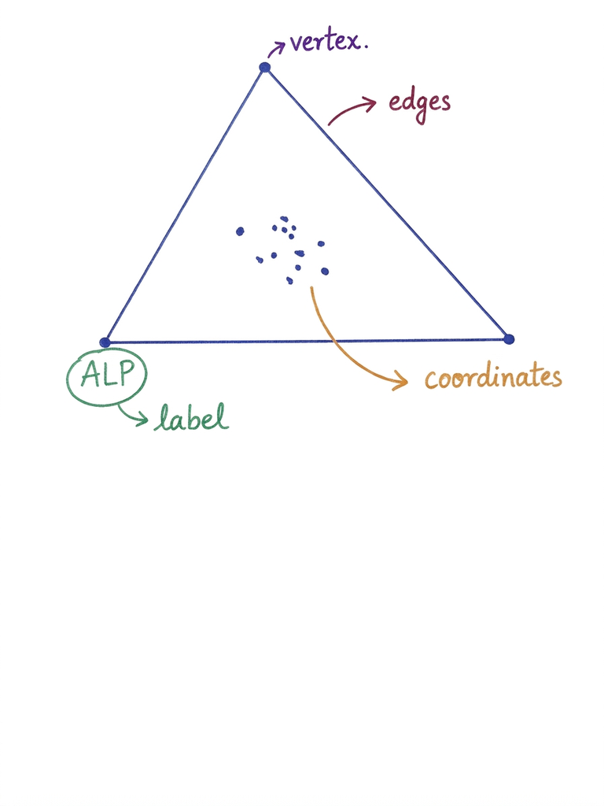

## First preference distribution

- Plot
- Code

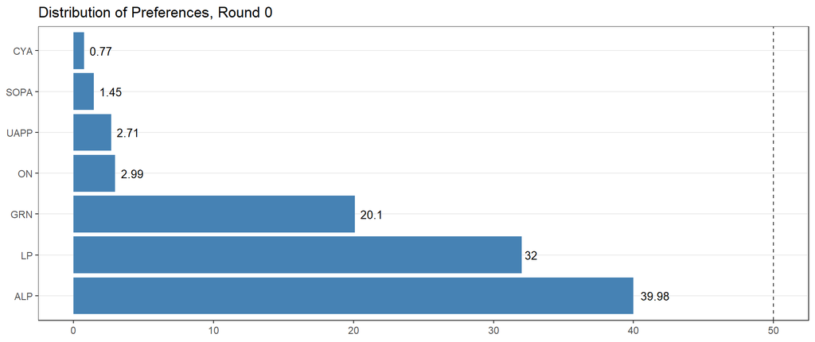

```r
long_df <- aecdop_2022 |>
  dplyr::filter(
    CalculationType == "Preference Percent",
    CountNumber == 0
  )
dop_bar(long_df, items = PartyAb, value_col = CalculationValue,
       round_col = "CountNumber", at_round = 0)
```

## Multiple electorates at once — ternary plot

- Plot
- Code

[interactive chart not shown]

```r
pref25_2d <- dop_transform(
  data              = pref25_2d,
  key_cols          = c(DivisionNm, CountNumber),
  value_col         = CalculationValue,
  item_col          = Party,
  winner_col        = Elected,
  winner_identifier = "Y"
)

tern_2d <- as_ternable(pref25_2d, items = ALP:Other)

input_data <- get_tern_data(tern_2d, plot_type = "2D")

ggplot(input_data |> filter(CountNumber == 0),
       aes(x = x1, y = x2)) +
  add_ternary_base() +
  geom_ternary_region(
    aes(fill = after_stat(vertex_labels)),
    vertex_labels = tern_2d$vertex_labels,
    alpha = 0.3, color = NA) +
  add_vertex_labels(tern_2d$simplex_vertices) +
  geom_point_interactive(
    aes(color = Winner, tooltip = text,
        data_id = DivisionNm))
```

## Flow of preference — path through ternary space

- Plot
- Code

[interactive chart not shown]

```r
line_input <- input_data |>
  filter(DivisionNm %in% c("Hotham", "Fowler", "Monash"))

ggplot(line_input, aes(x = x1, y = x2)) +
  add_ternary_base() +
  geom_ternary_region(
    aes(fill = after_stat(vertex_labels)),
    vertex_labels = tern_2d$vertex_labels,
    alpha = 0.3, color = "grey50") +
  add_vertex_labels(tern_2d$simplex_vertices) +
  stat_ordered_path(
    aes(group    = DivisionNm,
        order_by = CountNumber,
        color    = Winner),
    line.width = 0.5) +
  geom_point_interactive(
    aes(color   = pref1_party,
        tooltip = text,
        data_id = DivisionNm))
```

## Higher dimensions — `detourr` + `tourr`

- Plot
- Code

[interactive chart not shown]

```r
tern_hd <- as_ternable(pref25_hd, items = ALP:IND)

dtour_data <- tern_hd$simplex_vertices |>
  mutate(Winner = labels) |>
  bind_rows(get_tern_data(tern_hd, plot_type = "2D"))

detour(dtour_data,
       tour_aes(projection = x1:x4,
                colour = Winner,
                label  = text)) |>
  tour_path(grand_tour(3), fps = 60) |>
  show_scatter(
    axes    = FALSE,
    palette = party_colors,
    edges   = get_tern_edges(tern_hd),
    size    = 1.5)
```